# Climate Change is Disrupting the Salt Lake Valley

Bryan Williams

2020-10-14

## The Harrowing Effects of Rising Temperatures in Salt Lake City

Climate change is transforming the landscape of the Salt Lake Valley in Utah by eroding away precious snowpack and creating sweltering hot summers. Several peer-reviewed articles examine the impact that anthropogenic burning of fossil fuels has on local ecology, water resources, air quality, and snowpack. Climate change has created a trend of rising temperatures across the seasons in Utah, yielding several dire ecological, economic, and social implications including significantly hotter summers, shorter ski seasons, droughts, and exposure to toxic air pollution.

#### Scorching Salt Lake City

A recent study from ETH Zurich, a leading climatology research institute in Switzerland, analyzed the level of impact climate change has exerted on the Northern Hemisphere through a climate-analog study (Bastin, 2019). A climate analog study compares two different climates over time to demonstrate climate change impacts; in the case of this study, Salt Lake City is compared to Las Vegas. The study projects (a conservative estimate) that average Salt Lake City summer temperatures are likely to increase by 10 degrees Fahrenheit in the next 30 years. Thus, Salt Lake Valley summers may begin to feel closer to Las Vegas’s current scorching heat, increasing an average of 90 degrees to 100 degrees Fahrenheit.

#### Shrinking Water Resources and Ski Seasons

Climate change will likely reduce snowpack as winters warm. Snowpack is a critical resource for Salt Lake City, serving as a water resource for millions and an economic powerhouse in facilitating revenues from ski resorts (Seidel, 1998). Daily observation of snowpack telemetry (SNOTEL) data from 1981 to 2007 indicate that the overall level of snowfall has decreased significantly in the Great Salt Lake Basin (Bedford, 2007). This decreases the opportunity for the wintertime recreation and increases the chances of late-summer water shortages that are particularly potent as the population of the valley is rapidly increasing. The ski season in Utah is crucial, contributing $1.29 billion to Utah’s economy and creating 20,000 jobs. As winters continue to warm, these resources will continue to be threatened.

#### The Environmental Injustice of Air Pollution

While revenues from ski resorts are important to the city’s economy, there is a very pressing matter of environmental injustice: disparate air pollution damages. As anthropogenic fossil fuel burning continues to facilitate climate change, it also creates toxic air pollutants. Utah’s large metropolitan area, the Wasatch Front, has been notorious for trapping particulates, far exceeding the federal air quality standards set by the U.S. Environmental Protection Agency (EPA). The majority of communities that are exposed to this toxic air quality are Hispanic, Black, and Pacific Islander residents(Collins, 2019). This dire situation has led to a litany of health complications, including, but not limited to, asthma, cardiac diseases, and about 200 people hospitalized with severe pneumonia per year (Pirozzi, 2017). The EPA defines “orange” and “red” risk days as extremely dangerous, but even “green” days can perpetuate higher risk of death among the elderly in the Salt Lake Valley (Di, 2017). Several environmental adovcacy groups in the region, such as HEAL Utah, are figthing the deregulation of fossil fuel usage and air quality control (HEAL Utah, 2020). It is vital to prioritize the safety of Salt Lake City’s most disadvantaged communities. In order to take the first step in accomplishing this goal, one must first recognize and assess the problem. Therefore, I elected to conduct a climate data analysis in the region to understand the trends that facilitate these threats. This research ought to be useful for environmental advocates because it provides further precedence for the very real issue of anthropogenic climate change.

## The Climate Data Behind These Issues

To supplement this literature on climate change damages for the Salt Lake City populace, I analyzed temperature trend data in the Salt Lake Valley from 1942 to 2020 using NOAA satellite data collected by the Salt Lake International Airport Weather Station. I hypothesized that due to global climate change increasing temperatures in the region, temperatures would increase in the summer and winter and the winter snowfall would be decreased. The results indicate a significant increase in summer temperatures, increase in winter temperatures, and decrease in overall snowfall, supporting literature that these weather anomalies in Utah are climate change caused.

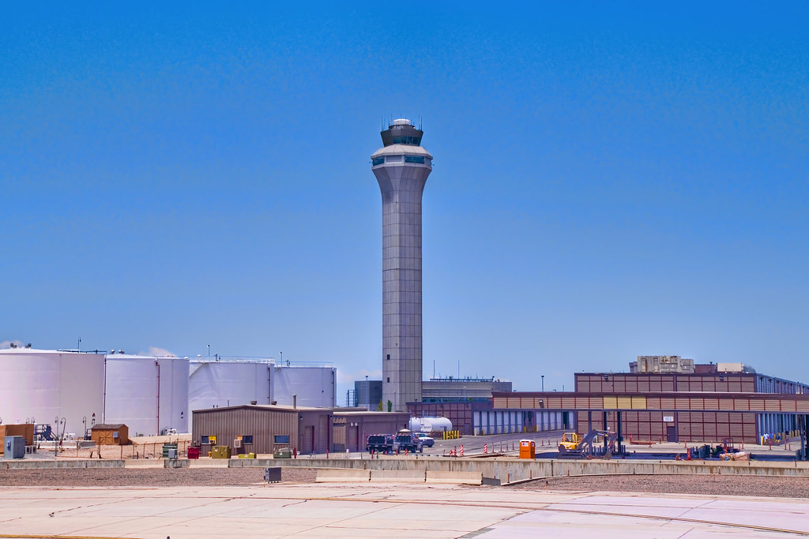

View from Salt Lake International Airport Weather Station in Salt Lake City, Utah

### Methods

Using R, I analyzed temperature trend data in the Salt Lake Valley from 1942 to 2020 using NOAA satellite data collected by the Salt Lake International Airport Weather Station. This weather station is central and topographically similar to the majority of the rest of the Salt Lake Valley, providing a representative sample. This station has been collecting robust daily data since the 1940s, charting temperature, precipitation, and other relevant climate variables so it is a great resource for this study.

I analyzed summer temperature data as well as winter temperature data and snowfall data. The variables measured are TMAX in July–the average daily maximum temperature, TMIN in January–the average daily minimum temperature, and average daily snowfall in January. July and January were selected because they represent the highest and lowest average points of temperature in the Valley, respectively. January also tends to have the highest rate of snowfall.

For each of the variables measured, a linear regression test was conducted to analyze and chart the satellite data. A linear model compares two variables over time, plots them in a slope (in this study’s case, temperature or snowfall over decades), and determines if there is a statistically significant correlation between them. If two variables are significantly correlated, that means that the trends are most likely not due to random chance, and instead, the variables influence one another.

When the slope has a p-value that is less than 0.05, the traditional threshold for determining statistical significance, the null hypothesis is rejected, meaning that the slope is likely not due to random chance. R-squared is a statistical measure of how close the data are to the regression line. Although the R-squared values are zero or close to zero in this study, this is to be expected for weather data given its high variability and the significant p-values are sufficient to draw conclusions.

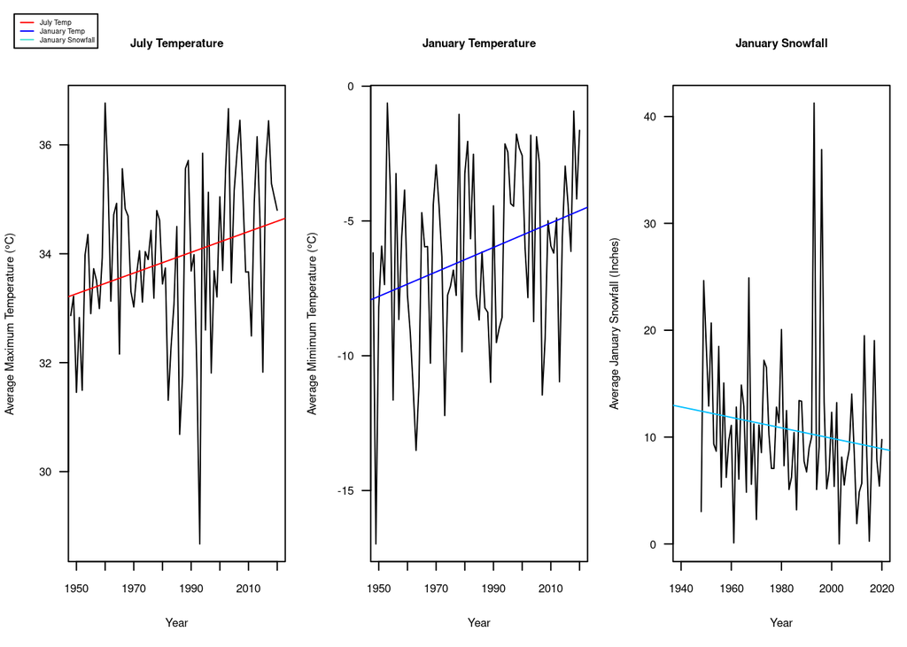

### Results

#### July is warming significantly

In Utah, it appears that our summer months have experienced warming. July was selected for the summer analysis because it is midsummer and one of the hottest months of the year. I have plotted July data below and have created a best-fit line (linear model/ordinary least squares model) for monthly July averages of `TMAX`(maximum daily temperature) against year to see if there is some type of discernible trend. Based on my analysis, my data indicate that there is a trend of increasing temperature in Salt Lake City for the month of July, rejecting the null hypothesis. (slope = 0.019, r2 = 0, p-value = 0.024).

#### January is warming significantly

It also appears that our winter months are experiencing warming. The month of January was selected for the winter analysis because it is midwinter, often receiving the highest level of monthly snowfall. I have plotted January data below and have created a best-fit line (linear model/ordinary least squares model) for monthly January averages of daily `TMIN` (minimum daily temperature) against year to see if there is some type of discernible trend. TMIN is used in place of TMAX here because we are concerned with low temperatures since it is the winter.

Based on my analysis, my data indicate that there is a significant trend of increasing temperature in Salt Lake City for the month of January, rejecting the null hypothesis (slope = 0.0435, r2 = 0, p-value = 0.029).

#### January snowfall is decreasing significantly

It also appears that our winter months have experienced decreasing snowfall. I’ve plotted January data below and have created a best-fit line (linear model/ordinary least squares model) for monthly January averages of daily snowfall against year to see if there is some type of discernible trend.

## This Trend Needs to Change to Protect People

The most important takeaway is not data–it is the effect that these trends have on people. For the sake of Utahn health and incomes, our goal as a city should be to reverse these climate change trends. Salt Lake City has lost up to $1 billion from smaller and poorer winters influenced by climate change and these impacts are only projected to worsen (Salt Lake Tribune, 2013). Accompanying climate change, as further fossil fuels are burned, the increasing intensity of air pollution causes significant respiratory complications, particularly for the least advantaged. Action on climate change, such as reducing reliance on fossil fuels and incorporating more sustainable infrastructure, is in the best interest of the people of Salt Lake City.

## Works Cited

Bastin, J.-F., Clark, E., Elliott, T., Hart, S., Hoogen, J. van den, Hordijk, I., Ma, H., Majumder, S., Manoli, G., Maschler, J., Mo, L., Routh, D., Yu, K., Zohner, C. M., & Crowther, T. W. (2019). Understanding climate change from a global analysis of city analogues. PLOS ONE, 14(7), e0217592. https://doi.org/10.1371/journal.pone.0217592

Bedford, D., & Douglass, A. (2008). Changing Properties of Snowpack in the Great Salt Lake

Basin, Western United States, from a 26-Year SNO℡ Record. The Professional Geographer, 60(3), 374–386. https://doi.org/10.1080/00330120802013646

Collins, T. W., & Grineski, S. E. (2019). Environmental Injustice and Religion: Outdoor Air Pollution Disparities in Metropolitan Salt Lake City, Utah. Annals of the American Association of Geographers, 109(5), 1597–1617. https://doi.org/10.1080/24694452.2018.1546568

Di, Q., Dai, L., Wang, Y., Zanobetti, A., Choirat, C., Schwartz, J. D., & Dominici, F. (2017). Association of Short-term Exposure to Air Pollution With Mortality in Older Adults. JAMA, 318(24), 2446. https://doi.org/10.1001/jama.2017.17923

Herald, B. H.-D. (n.d.). Winter sports industry crucial to Utah economy. Daily Herald. Retrieved October 10, 2020, from https://www.heraldextra.com/business/local/winter-sports-industry-crucial-to-utah-economy/article_5ecca646-e487-553c-98f5-e8ea04da8ff1.html

ISSUE: Clean Air Act. (2020, May 18). HEAL Utah. https://www.healutah.org/blog-issue-clean-air-act/

Pirozzi, C. S., Jones, B. E., VanDerslice, J. A., Zhang, Y., Paine, R., & Dean, N. C. (2017). Short-Term Air Pollution and Incident Pneumonia. A Case–Crossover Study. Annals of the American Thoracic Society, 15(4), 449–459. https://doi.org/10.1513/AnnalsATS.201706-495OC

Report: Global warming hits Utah’s ski industry hard. (n.d.). The Salt Lake Tribune. Retrieved October 10, 2020, from https://archive.sltrib.com/article.php?id=55416130&itype=CMSID S, J. (2017, February 28). Wasatch Weather Weenies: Is March Really Utah’s Snowiest Month?

Wasatch Weather Weenies. https://wasatchweatherweenies.blogspot.com/2017/02/is-march-really-utahs-snowiest-month.html Salt Lake City-Provo-Orem, UT. (n.d.). American Lung Association. Retrieved October 10, 2020, from https://www.stateoftheair.org/city-rankings/msas/salt-lake-city-provo-orem-ut.html

Seidel, K., Ehrler, C., & Martinec, J. (1998). Effects of climate change on water resources and runoff in an Alpine basin. Hydrological Processes, 12(10–11), 1659–1669. https://doi.org/10.1002/(SICI)1099-1085(199808/09)12:10/11<1659::AID-HYP687>3.0.CO;2-4